# An Introduction to the ‘adjustedCurves’ Package

The main purpose of the “adjustedCurves” R-Package is to calculate and plot confounder-adjusted survival curves and cause-specific confounder-adjusted cumulative incidence functions (CIF) using a variety of methods. Group- or treatment-specific survival curves and cumulative incidence functions are often used to graphically display the treatment (or group) effect on the survival probability. When the data at hand comes from a randomized controlled trial with balanced subgroups, simple stratified estimators of the survival curves or CIFs are unbiased. When randomization fails or was not done at all however, confounding can lead to biased depictions (see Rubin 1974; Pearl 2009).

Luckily, a lot of different methods to adjust survival curves and CIFs for confounding have been proposed. With the **adjustedCurves** package, these methods can be used with little effort. For a small review and simulation study of all methods see Denz et al. (2021).

## Installation

The R-Package is currently not available on CRAN, but can be installed easily using the **devtools** package:

```r
#library(devtools)
#devtools::install_github("RobinDenz1/adjustedCurves")
```

```r
#library(remotes)
#remotes::install_github("RobinDenz1/adjustedCurves")
```

Further packages might have to be installed, depending on the specified method.

## Adjusted Survival Curves

Let’s start with the standard survival setting. Using the **sim_confounded_surv** function, we simulate some survival data (Chatton et al. 2020):

```r
library(survival)
library(ggplot2)
library(adjustedCurves)

# set random number generator seed to make this reproducible
set.seed(41)

# simulate standard survival data with 300 rows
data <- sim_confounded_surv(n=300)
# code the grouping variable as a factor
data$group <- as.factor(data$group)

# take a look at the first few rows
head(data)
```

```
##   x1 x2 x3         x4         x5         x6 group      time event
## 1  0  1  1  0.3009753 -0.8457787 -1.0629242     0 0.5877590     1
## 2  1  1  1 -0.4246957  1.2526557 -0.9759365     0 0.2620015     1
## 3  1  0  1  1.2758093 -0.6487439  0.4174419     1 0.7492255     0
## 4  0  0  0 -0.3353432 -0.3888960 -1.3187617     0 0.6344717     1
## 5  1  1  0  1.1226585 -2.0605362 -2.2049385     0 0.6684994     1
## 6  1  1  1 -1.1457605 -0.6020554 -0.9689735     0 0.4787611     1
```

Using the default arguments, this function outputs a data.frame with 6 independently drawn covariates (x1 - x6), a binary group variable (“group”), the observed event time (“time”) and the event indicator (“event”). In this setting, there is only one type of event (“1”). When the observations are right-censored this indicator is set to “0”. This is the standard data format used in standard time-to-event analysis.

### Direct Standardization

To calculate confounder-adjusted survival curves fo each group of this dataset using *Direct Standardization* (also known as *G-Computation* or *Corrected Group Prognosis method*, see Makuch (1982) or Chang et al. (1982)), we first have to fit a **coxph** model:

```r
# it is important to use X=TRUE in the coxph function call
outcome_model <- survival::coxph(Surv(time, event) ~ x1 + x2 + x3 + x4 + x5 + x6 + group,
                                 data=data, x=TRUE)
```

This model can then be used in a call to the **adjustedsurv** function, as shown below:

```r
adjsurv <- adjustedsurv(data=data,
                        variable="group",
                        ev_time="time",
                        event="event",
                        method="direct",
                        outcome_model=outcome_model,
                        conf_int=T)
```

The argument **data** simply refers to our data.frame, the argument **variable** specifies our grouping variable of interest and the **ev_time** and **event** variable specify the time-to-event variables in our data.frame. Setting the **method** to “direct” will result in G-Computation estimates, based on the previously fit cox-regression model supplied using the **outcome_model** argument.

Doing this returns a list with some needed output objects. Most important however is the **adjsurv** object in there, containing the adjusted survival curves and correspongind confidence intervals (because **conf_int=TRUE** in the original function call). We can take a look at this object using the following code:

```r
head(adjsurv$adjsurv)
```

```
##         time      surv group          se  ci_lower  ci_upper
## 1 0.00000000 1.0000000     0 0.000000000 1.0000000 1.0000000
## 2 0.02658129 0.9949071     0 0.005084115 0.9849424 1.0000000
## 3 0.07269126 0.9896378     0 0.007339014 0.9752536 1.0000000
## 4 0.07803725 0.9843642     0 0.009036205 0.9666536 1.0000000
## 5 0.08092329 0.9790929     0 0.010413691 0.9586824 0.9995034
## 6 0.09065350 0.9738343     0 0.011570813 0.9511559 0.9965126
```

More importantly however, we can plot the survival curves directly using the **plot** method:

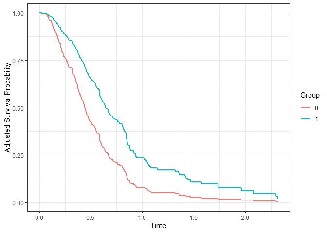

```r
plot(adjsurv)
```

This plot function comes with many options which are listed in the documenation. To plot the pointwise confidence intervals, we can set the argument **draw_ci** to TRUE:

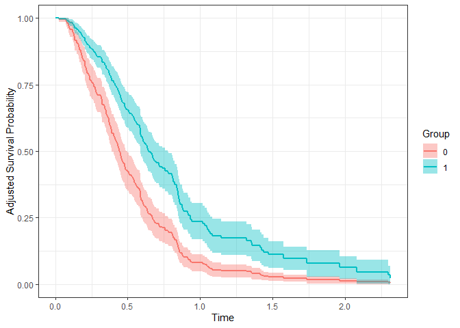

```r
plot(adjsurv, draw_ci=TRUE)
```

Instead of using colors to differentiate the curves we can also use different linetypes, by setting the **linetype** argument to TRUE and the **color** argument to FALSE:

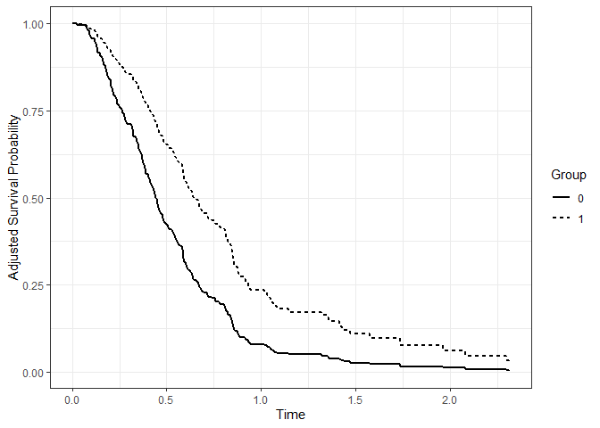

```r
plot(adjsurv, linetype=TRUE, color=FALSE)
```

Many more custom settings are available. For more details and examples see **?plot.adjustedsurv**.

### Inverse Probability of Treatment Weighting

The **adjustedsurv** function essentially works the same with every available method. Since the methods are however vastly different in nature, some additional arguments have to be supplied by the user. For example, using the Inverse Probability of Treatment Weighting method (IPTW), we need to model the *treatment assignment* instead of the outcome model (see Xie and Liu (2005)). This can be done using a logistic regression model as follows:

```r
treatment_model <- glm(group ~ x1 + x2 + x3 + x4 + x5 + x6,
                       data=data, family="binomial"(link="logit"))

adjsurv <- adjustedsurv(data=data,
                        variable="group",
                        ev_time="time",
                        event="event",
                        method="iptw_km",
                        treatment_model=treatment_model,
                        conf_int=T)
```

The resulting curves can be plotted as before:

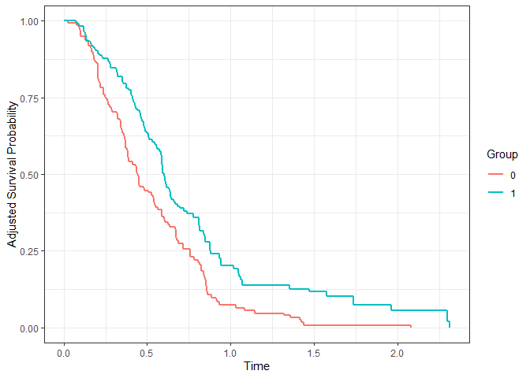

```r
plot(adjsurv)
```

Since both methods were used correctly here, there are only slight differences in the results. Big differences between the two methods usually indicate that either the cox-regression model or the logistic regression model are incorrectly specified.

### Augmented Inverse Probabiltiy of Treatment Weighting

Doubly-Robust methods can be helpful in such cases (see Robins and Rotnitzky (1992) or Ozenne et al. (2020)). The standard Augmented Inverse Probability of Treatment Weighting estimator utilized both kinds of models at the same time. If either of the models is correctly specified, the resulting estimates will be unbiased. It can be used in the same way as the other methods, only that this time both models have to be supplied:

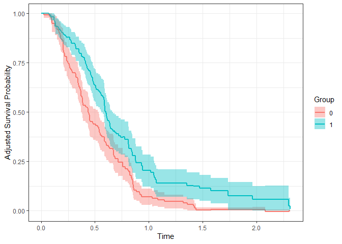

```r
treatment_model <- glm(group ~ x1 + x2 + x3 + x4 + x5 + x6,
                       data=data, family="binomial"(link="logit"))

outcome_model <- survival::coxph(Surv(time, event) ~ x1 + x2 + x3 + x4 + x5 + x6 + group,
                                 data=data, x=TRUE)

adjsurv <- adjustedsurv(data=data,
                        variable="group",
                        ev_time="time",
                        event="event",
                        method="aiptw",
                        treatment_model=treatment_model,
                        outcome_model=outcome_model,
                        conf_int=T)

plot(adjsurv, draw_ci=T)
```